# load modules

```python
import numpy as np
from matplotlib import pyplot as plt
import cv2
import glob
```

```python
# load images (pngs)
images = glob.glob('../images/**.png')
```

## loading images

loading rgb images as rgb images and greyscale images.

```python
# load as color image
img = cv2.imread(images[0], cv2.IMREAD_COLOR)

# load as grayscale
img_grey = cv2.imread(images[0], cv2.IMREAD_GRAYSCALE)
```

[figure not shown]

```python
# display color and grayscale images
fig, axes = plt.subplots(1, 2, figsize=(4, 4), sharex=True, sharey=True)
ax = axes.ravel()

ax[0].set_title("Original color image")
ax[0].imshow(img[...,::-1], interpolation = "nearest")

ax[1].set_title("Image as grayscale")
ax[1].imshow(img_grey, cmap=plt.cm.Greys_r, interpolation = "nearest")

for a in ax:
    a.set_axis_off()

fig.tight_layout()
plt.show()
```

Alternatively, you can use integers (1, 0, -1) as flags *in lieu* of writing out `cv2.IMREAD_COLOR`, `cv2.IMREAD_GRAYSCALE`, *etc.*

```python
# load color image
img = cv2.imread(images[0], 1)

# load as greyscale
img_grey = cv2.imread(images[0], 0)
```

## Numpy and OpenCV

With OpenCV, we work with large numpy arrays.

- For **color** images, they are 3 dimensional arrays.
- And **grayscale** images, they are 2 dimensional.

```python
print('Color image\n-------\nImage shape: {}\ntype: {}\nData type: {}\nDimensions: {}'
      .format(img.shape, type(img), img.dtype, img.ndim)
     )
```

```
Color image
-------
Image shape: (512, 512, 3)
type: <class 'numpy.ndarray'>
Data type: uint8
Dimensions: 3
```

```python
print('Grayscale image\n-------\nImage shape: {}\ntype: {}\nData type: {}\nDimensions: {}'
      .format(img_grey.shape, type(img_grey), img_grey.dtype, img_grey.ndim)
     )
```

```
Grayscale image
-------
Image shape: (512, 512)
type: <class 'numpy.ndarray'>
Data type: uint8
Dimensions: 2
```

## Cropping images

Okay, let's examine a small section of the image (region of interest (ROI)). Selecting the eye of the lenna.png.

For our grayscaled image,

- img_gray[0,0] = top-left pixel intensity value

For the color image,

- img[0,0,0] = top-left pixel value in our Blue channel (we'll discuss this below)

```python
# select region of interest using numpy indexing
img_roi = img_grey[250:280, 240:295]
```

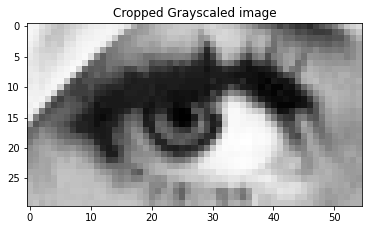

```python
# plot  image
plt.title("Cropped Grayscaled image")
plt.imshow(img_roi, cmap=plt.cm.Greys_r, interpolation = "nearest")
plt.show()
```

```python
print(img_roi)
```

```
[[199 197 180 ... 157 166 174]
 [200 192 174 ... 131 146 158]
 [197 188 169 ... 110 131 145]
 ...
 [149 144 146 ... 139 137 142]
 [151 151 149 ... 137 143 144]
 [151 156 146 ... 142 144 144]]
```

# Color format

**BGR** –> Blue intensity, Green intensity, and Red intensity

```python
# splitting the color channels
b, g, r = cv2.split(img)
```

[figure not shown]

```python
# display color channels
fig, axes = plt.subplots(1, 3, figsize=(6, 6), sharex=True, sharey=True)
ax = axes.ravel()

ax[0].set_title("Blue Channel")
ax[0].imshow(b, cmap=plt.cm.Blues, interpolation = "nearest")

ax[1].set_title("Green Channel")
ax[1].imshow(g, cmap=plt.cm.Greens, interpolation = "nearest")

ax[2].set_title("Red Channel")
ax[2].imshow(r, cmap=plt.cm.Reds, interpolation = "nearest")

for a in ax:
    a.set_axis_off()

fig.tight_layout()
plt.show()
```

[figure not shown]

```python
# recombine separated channels
recombined = cv2.merge((b, g, r))

# Recombine separated channels
plt.title("Recombined channels")
plt.imshow(recombined[...,::-1], interpolation = "nearest")
plt.show()
```

# Converting between color format

The keen-eyed may have noticed that when plotting with matplotlib above, we reindexed our color image before plotting `img[...,::-1]`. OpenCV loads images in BGR mode, however, matplotlib and other software use RGB. Therefore, here, we reordered the image dimensions (the color channels) to reflect appear correctly.

```python
# convert to rgb
img_rgb = cv2.cvtColor(img, cv2.COLOR_BGR2RGB)
```

[figure not shown]

```python
# display original color and BGR converted image
fig, axes = plt.subplots(1, 3, figsize=(8, 3), sharex=True, sharey=True)
ax = axes.ravel()

ax[0].set_title("BGR")
ax[0].imshow(img, interpolation = "nearest")

ax[1].set_title("Reversed channels")
ax[1].imshow(img[...,::-1], interpolation = "nearest")

ax[2].set_title("BGR –> RGB")
ax[2].imshow(img_rgb, interpolation = "nearest")

for a in ax:
    a.set_axis_off()

fig.tight_layout()
plt.show()
```